# Regressão quantílica em modelos mistos

Álvaro Kothe

14/12/2021

# Regressão quantílica

- Qualquer variável aleatória pode ser caracterizada pela sua função de distribuição acumulada $F(y) = P(Y \leq y)$;
- Na regressão quantílica, é possível caracterizar toda a distribuição condicional da variável resposta;
- Robusto a valores discrepantes e a especificação incorreta da distribuição dos erros;

# Exemplo de robustez da regressão quantílica

Dados de 235 observações sobre o gasto em alimentação e renda em casas Belgas.

```r
data("engel")

engel
```

|  | income | foodexp |
| --- | --- | --- |
| 1 | 420.1577 | 255.8394 |
| 2 | 541.4117 | 310.9587 |
| 3 | 901.1575 | 485.6800 |
| 4 | 639.0802 | 402.9974 |
| 5 | 750.8756 | 495.5608 |
| 6 | 945.7989 | 633.7978 |
| 7 | 829.3979 | 630.7566 |
| 8 | 979.1648 | 700.4409 |
| 9 | 1309.8789 | 830.9586 |
| 10 | 1492.3987 | 815.3602 |

[output cut: 225 more lines]

Gasto em comida muito acima dos demais

```r
engel %>% filter(foodexp > 2000)
```

|  | income | foodexp |
| --- | --- | --- |
| 59 | 2822.533 | 2032.679 |

Criando um valor discrepante e comparando o valor dos coeficientes

```r
engel_o <- engel %>% mutate(foodexp = ifelse(foodexp > 2000, 99999, foodexp))

lm1 <- lm(foodexp ~ income, data = engel)
lm2 <- lm(foodexp ~ income, data = engel_o)

rq1 <- rq(foodexp ~ income, tau = .5, data = engel)
rq2 <- rq(foodexp ~ income, tau = .5, data = engel_o)
```

```r
cbind(
  "Linear S/ Outlier" = coef(lm1), "Linear C/ Outlier" = coef(lm2),
  "RQ S/ Outlier" = coef(rq1), "RQ C/ Outlier" = coef(rq2)
)
```

```
##             Linear S/ Outlier Linear C/ Outlier RQ S/ Outlier RQ C/ Outlier
## (Intercept)       147.4753885      -2242.970677    81.4822474    81.4822474
## income              0.4851784          3.342584     0.5601806     0.5601806
```

# Distribuição Laplace Assimétrica (ALD)

$Y$ possui distribuição $\mbox{ALD}(\mu, \sigma, p)$, com função de densidade
$$f(y|\mu, \sigma, p) = \frac{p(1-p)}{\sigma} \exp
\left\{
-\rho_p \left ( \frac{y - \mu}{\sigma}\right)
\right\}$$

- $\mu \in R$ é o parâmetro de locação;
- $\sigma > 0$ é o parâmetro de escala;
- $p \in (0, 1)$ é o parâmetro de assimetria;
- $\rho_p(u) = u(p - I\{u < 0\})$ é a função de perda;

# Parâmetro de assimetria da ALD

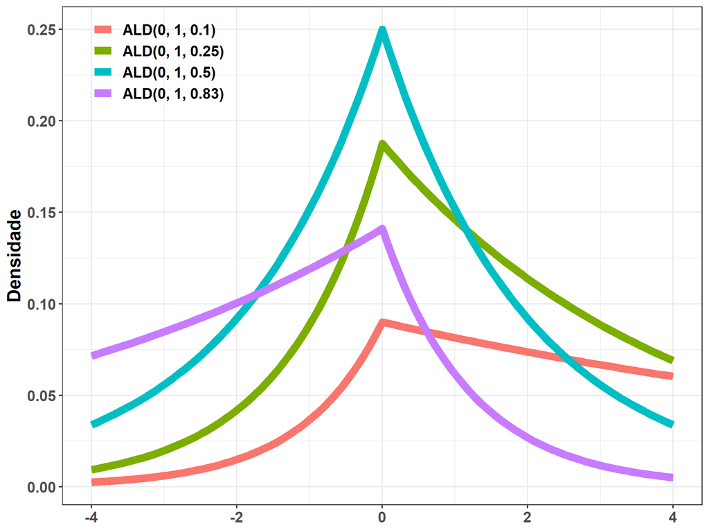

# Regressão quantílica em modelos mistos

O modelo apresentado por Galarza, Lachos, and Bandyopadhyay (2016) para o $p$-ésimo quantil condicional da variável resposta $y_{ij}$ é definido como:
$$Q_p(y_{ij}|\boldsymbol{x_{ij}, b_i}) = \boldsymbol x_{ij}^T \boldsymbol \beta_p + \boldsymbol{z_{ij} b_i}$$

para $i = 1, \dots, n$ e $j = 1, \dots, n_i$

- $y_{ij}$ é a $j$-ésima medida do $i$-ésimo sujeito
- $x_{ij}$ é um vetor de dimensão $1 \times k$
- $\boldsymbol{z_{ij}}$ é um vetor de dimensão $q \times 1$
- $Q_p$ é a função inversa de uma distribuição desconhecida $F(\cdot)$
- $\boldsymbol \beta_p$ é o coeficiente de regressão dos efeitos fixos para o p-ésimo quantil com dimensão $k \times 1$
- $\boldsymbol b_i$ são os efeitos aleatórios com distribuição $\boldsymbol b_i \sim N_q(\boldsymbol{0, \Psi})$

Segundo Galarza Lachos et al. (2016) o resíduo tem uma distribuição $\mbox{ALD}(0, \sigma)$, e $y_{ij}| \boldsymbol b_i$ são independentes com distribuição ALD com densidade
$$f(y|\mu, \sigma, p) = \frac{p(1-p)}{\sigma} \exp
\left\{
-\rho_p \left ( \frac{y -
\boldsymbol x_{ij}^T \boldsymbol \beta_p - \boldsymbol{z_{ij} b_i}}{\sigma}\right)
\right\}$$

# Exemplo com o banco de dados `Orthodont`

Dados referentes a medidas ortodônticas em crianças.

```r
data("Orthodont")

Orthodont$Subject <- factor(
  Orthodont$Subject,
  sort(unique(as.character(Orthodont$Subject)))
)

Orthodont
```

|  | distance | age | Subject | Sex |
| --- | --- | --- | --- | --- |
| 1 | 26.0 | 8 | M01 | Male |
| 2 | 25.0 | 10 | M01 | Male |
| 3 | 29.0 | 12 | M01 | Male |
| 4 | 31.0 | 14 | M01 | Male |
| 5 | 21.5 | 8 | M02 | Male |
| 6 | 22.5 | 10 | M02 | Male |
| 7 | 23.0 | 12 | M02 | Male |
| 8 | 26.5 | 14 | M02 | Male |
| 9 | 23.0 | 8 | M03 | Male |
| 10 | 22.5 | 10 | M03 | Male |

[output cut: 98 more lines]

# Pacote `qrLMM`

Argumentos da função `QRLMM(y,x,z,groups,p=0.5)`:

- `y` é o vetor resposta de dimensão $N$
- `x` é a matriz de delineamento com os efeitos fixos de dimensão $N \times k$
- `z` é a matriz de delineamento com os efeitos aleatórios de dimensão $N \times q$
- `groups` fator definindo a partição dos efeitos aleatórios de dimensão $N$
- `p` define o quantil ajustado

# Exemplo dos autores

```r
y <- Orthodont$distance # response
x <- cbind(1, c(rep(0, 64), rep(1, 44)), Orthodont$age) # design matrix for fixed effects
z <- cbind(1, Orthodont$age) # design matrix for random effects
groups <- Orthodont$Subject
```

Invés de definir na mão como os autores fizeram, poderia usar a função `model.matrix` para definir `x` e `z`.

```r
x <- model.matrix(~ Sex + age, data = Orthodont)
z <- model.matrix(~age, data = Orthodont)
```

### Matrizes

#### y

| y |
| --- |
| 26.0 |
| 25.0 |
| 29.0 |
| 31.0 |
| 21.5 |
| 22.5 |
| 23.0 |
| 26.5 |
| 23.0 |
| 22.5 |

[output cut: 98 more lines]

#### x

| V1 | V2 | V3 |
| --- | --- | --- |
| 1 | 0 | 8 |
| 1 | 0 | 10 |
| 1 | 0 | 12 |
| 1 | 0 | 14 |
| 1 | 0 | 8 |
| 1 | 0 | 10 |
| 1 | 0 | 12 |
| 1 | 0 | 14 |
| 1 | 0 | 8 |
| 1 | 0 | 10 |

[output cut: 98 more lines]

#### z

| V1 | V2 |
| --- | --- |
| 1 | 8 |
| 1 | 10 |
| 1 | 12 |
| 1 | 14 |
| 1 | 8 |
| 1 | 10 |
| 1 | 12 |
| 1 | 14 |
| 1 | 8 |
| 1 | 10 |

[output cut: 98 more lines]

#### groups

| groups |
| --- |
| M01 |
| M01 |
| M01 |
| M01 |
| M02 |
| M02 |
| M02 |
| M02 |
| M03 |
| M03 |

[output cut: 98 more lines]

# Ajuste do modelo para os quantis 10%, 50% e 90% utilizando o pacote `qrLMM`

```r
taus <- c(.1, .5, .9)

fit_qrlmm <- QRLMM(y, x, z, groups,
  p = taus, MaxIter = 50,
  show.convergence = FALSE
)
```

```
##
## ---------------------------------------------------
## Quantile Regression for Linear Mixed Model
## ---------------------------------------------------
##
## Quantile = 0.1 0.5 0.9
## Subjects = 27 ; Observations = 108 ; Balanced = 4
##
## -----------
## Estimates
## -----------
##
## - Fixed effects
##
##        Estimate Std. Error Inf CI95% Sup CI95%  z value Pr(>|z|)
## beta 1 15.76202    0.76412  14.26434  17.25970 20.62763        0
## beta 2 -2.48957    0.47497  -3.42051  -1.55863 -5.24155        0
## beta 3  0.63404    0.07381   0.48937   0.77870  8.59010        0
##
## sigma = 0.18876
##
## Random effects Variance-Covariance Matrix matrix
##         z1      z2
## z1 0.72286 0.04653
## z2 0.04653 0.02127
##
## ------------------------
## Model selection criteria
## ------------------------
##
##         Loglik     AIC     BIC      HQ
## Value -228.666 471.332 490.107 478.944
##
## -------
## Details
## -------
##
## Convergence reached? = FALSE
## Iterations = 50 / 50
## Criteria = 0.00667
```

[output cut: 72 more lines]

```
## ------------------------
##
##         Loglik    AIC     BIC      HQ
## Value -225.355 464.71 483.485 472.322
##
## -------
## Details
## -------
##
## Convergence reached? = FALSE
## Iterations = 50 / 50
## Criteria = 0.05032
## MC sample = 10
## Cut point = 0.25
## Processing time = 21.80294 secs
```

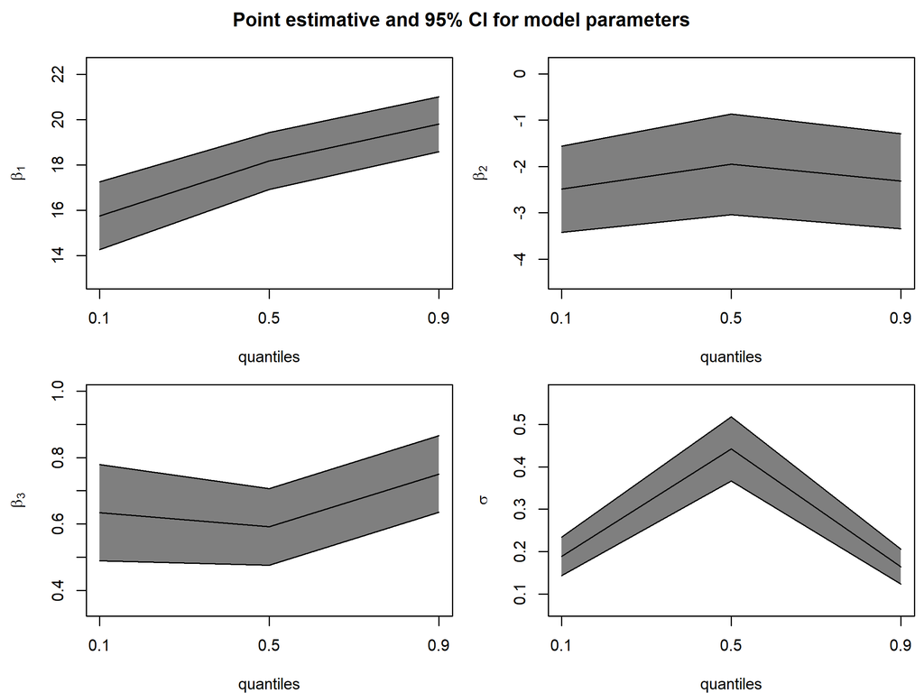

# Predição para `QRLMM`

Os autores não definiram um método `predict`, por isso devemos devemos calcular as estimativas manualmente.

```r
predict_qrlmm <- function(model, x, z = NULL, groups = NULL) {
  beta <- model$res$beta # fixed effects
  weights <- model$res$weight # random weights
  fixed <- tcrossprod(x, t(beta))
  random <- rep(0, dim(x)[1]) # initializing random shift

  if (!(is.null(z) || is.null(groups))) {
    nj <- c(as.data.frame(table(groups))[, 2]) # obs per subject
    for (j in 1:length(nj)) {
      z1 <- matrix(z[(sum(nj[1:j - 1]) + 1):(sum(nj[1:j])), ],
        ncol = dim(z)[2]
      )

      random[(sum(nj[1:j - 1]) + 1):(sum(nj[1:j]))] <-
        tcrossprod(z1, t(weights[j, ]))
    }
  }

  pred <- fixed + random # predictions

  pred
}
```

```r
pred_qrlmm_1 <- lapply(fit_qrlmm, predict_qrlmm, x, z, groups)
pred_qrlmm_0 <- lapply(fit_qrlmm, predict_qrlmm, x)
```

```r
update_geom_defaults("line", list(size = 1.2, alpha = .6))
```

### Estimativas por indivíduo

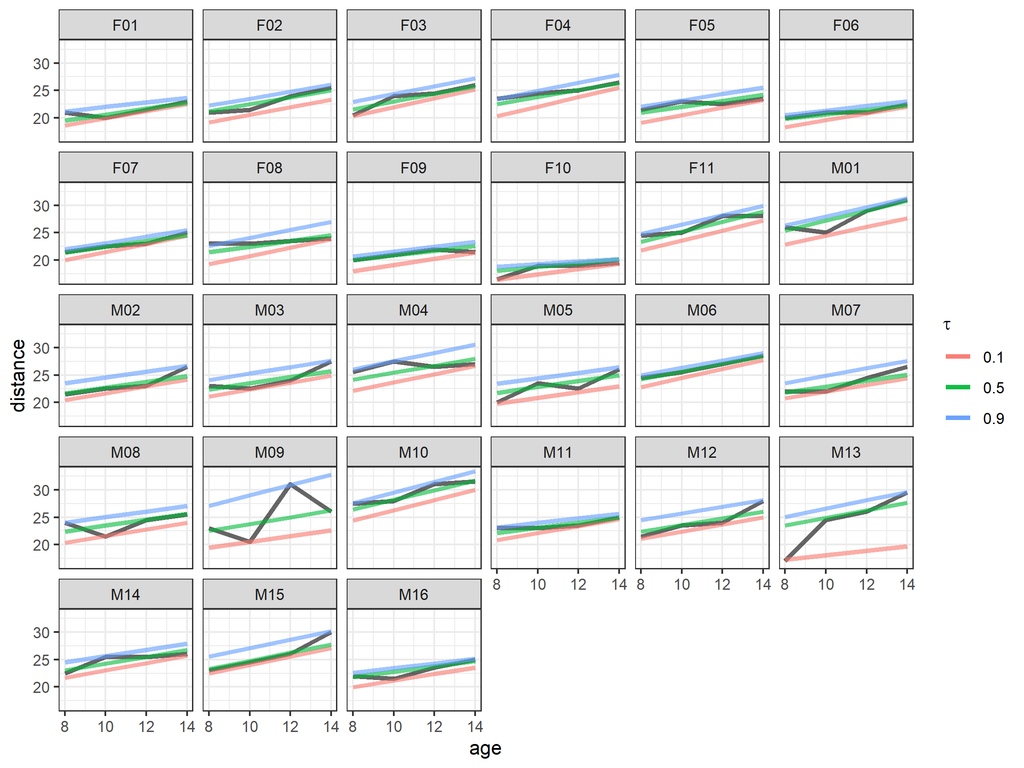

```r
ggplot(Orthodont, aes(age, distance)) +
  geom_line() +
  {
    purrr::map2(
      pred_qrlmm_1, as.character(taus),
      ~ geom_line(aes(y = .x, color = .y))
    )
  } +
  facet_wrap(~Subject) +
  labs(color = TeX("$\\tau$"))
```

### Estimativas populacionais por sexo

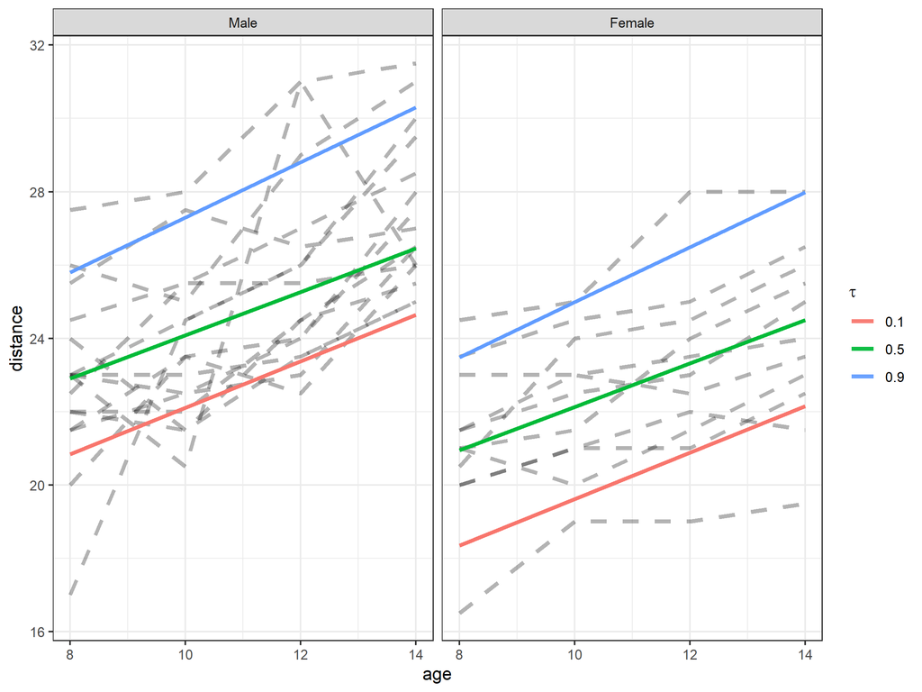

```r
ggplot(Orthodont, aes(age, distance, group = Subject)) +
  geom_line(alpha = .3, linetype = 2) +
  {
    purrr::map2(
      pred_qrlmm_0, as.character(taus),
      ~ geom_line(aes(y = .x, color = .y))
    )
  } +
  facet_wrap(~Sex) +
  labs(color = TeX("$\\tau$")) +
  theme_bw()
```